# Predicition Assignment

##Prediction Assignment - Practical Machine Learning Coursera Michael D 04 January 2021

##Overview Using devices such as Jawbone Up, Nike FuelBand, and Fitbit it is now possible to collect a large amount of data about personal activity relatively inexpensively. These type of devices are part of the quantified self movement - a group of enthusiasts who take measurements about themselves regularly to improve their health, to find patterns in their behavior, or because they are tech geeks. One thing that people regularly do is quantify how much of a particular activity they do, but they rarely quantify how well they do it. In this project, your goal will be to use data from accelerometers on the belt, forearm, arm, and dumbell of 6 participants. They were asked to perform barbell lifts correctly and incorrectly in 5 different ways. More information is available from the website here: http://groupware.les.inf.puc-rio.br/har (see the section on the Weight Lifting Exercise Dataset).

```r
library(caret)
```

```r
library(rpart)
library(rpart.plot)
library(randomForest)
library(gbm)
library(plyr)
library(rattle)
set.seed(12345)

##Cleaning the Data
download.file(url = "https://d396qusza40orc.cloudfront.net/predmachlearn/pml-training.csv",
              destfile = "./pml-training.csv", method = "curl")

dt_training <- read.csv("./pml-training.csv", na.strings=c("NA","#DIV/0!",""))

download.file(url = "https://d396qusza40orc.cloudfront.net/predmachlearn/pml-testing.csv",
              destfile = "./pml-testing.csv", method = "curl")

dt_testing <- read.csv("./pml-testing.csv", na.strings=c("NA","#DIV/0!",""))

features <- names(dt_testing[,colSums(is.na(dt_testing)) == 0]) [8:59]

dt_training <- dt_training[,c(features,"classe")]
dt_testing <- dt_testing[,c(features, "problem_id")]

dim(dt_training); dim(dt_testing);
```

```
## [1] 19622    53
```

```
## [1] 20 53
```

```r
set.seed(12345)

inTrain <- createDataPartition(dt_training$classe, p=0.6, list=FALSE)
training <- dt_training[inTrain,]
testing <- dt_training[-inTrain,]

dim(training); dim(testing);
```

```
## [1] 11776    53
```

```
## [1] 7846   53
```

[figure not shown]

```r
##Decsision Tree Model
modFitDT <- rpart(classe ~ ., data = training,
                  method="class", control = rpart.control(method = "cv", number = 10))
fancyRpartPlot(modFitDT)
```

```r
##Decision Tree Prediction
prediction <- predict(modFitDT, testing, type = "class")
test_classe <- as.factor(testing$classe)
confusionMatrix(prediction, test_classe)
```

```
## Confusion Matrix and Statistics
##
##           Reference
## Prediction    A    B    C    D    E
##          A 1995  246   49   83   51
##          B   75  890  111  119  115
##          C   44  198 1094  153  143
##          D   74  112   79  840   94
##          E   44   72   35   91 1039
##
## Overall Statistics
##
##                Accuracy : 0.7466
##                  95% CI : (0.7368, 0.7562)
##     No Information Rate : 0.2845
##     P-Value [Acc > NIR] : < 2.2e-16
##
##                   Kappa : 0.6787
##
##  Mcnemar's Test P-Value : < 2.2e-16
##
## Statistics by Class:
##
##                      Class: A Class: B Class: C Class: D Class: E
## Sensitivity            0.8938   0.5863   0.7997   0.6532   0.7205
## Specificity            0.9236   0.9336   0.9169   0.9453   0.9622
## Pos Pred Value         0.8230   0.6794   0.6703   0.7006   0.8111
## Neg Pred Value         0.9563   0.9039   0.9559   0.9329   0.9386
## Prevalence             0.2845   0.1935   0.1744   0.1639   0.1838
## Detection Rate         0.2543   0.1134   0.1394   0.1071   0.1324
## Detection Prevalence   0.3089   0.1670   0.2080   0.1528   0.1633
## Balanced Accuracy      0.9087   0.7600   0.8583   0.7992   0.8414
```

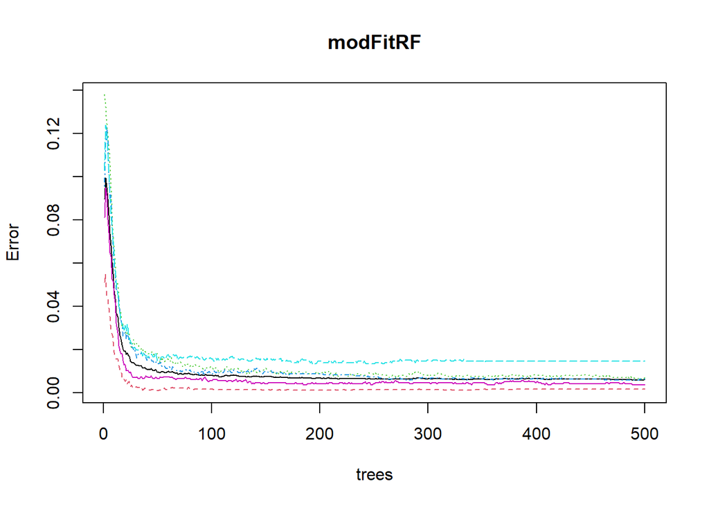

```r
##Random Forest Model
training$classe <- as.factor(training$classe)
modFitRF <- randomForest(classe ~ ., data = training, method = "rf", importance = T, trControl = trainControl(method = "cv", classProbs=TRUE,savePredictions=TRUE,allowParallel=TRUE, number = 10))

plot(modFitRF)
```

```r
##Random Forest Predicition
prediction <- predict(modFitRF, testing, type = "class")
test_classe <- as.factor(testing$classe)
confusionMatrix(prediction, test_classe)
```

```
## Confusion Matrix and Statistics
##
##           Reference
## Prediction    A    B    C    D    E
##          A 2230    4    0    0    0
##          B    2 1514    5    0    0
##          C    0    0 1359    6    2
##          D    0    0    4 1279    5
##          E    0    0    0    1 1435
##
## Overall Statistics
##
##                Accuracy : 0.9963
##                  95% CI : (0.9947, 0.9975)
##     No Information Rate : 0.2845
##     P-Value [Acc > NIR] : < 2.2e-16
##
##                   Kappa : 0.9953
##
##  Mcnemar's Test P-Value : NA
##
## Statistics by Class:
##
##                      Class: A Class: B Class: C Class: D Class: E
## Sensitivity            0.9991   0.9974   0.9934   0.9946   0.9951
## Specificity            0.9993   0.9989   0.9988   0.9986   0.9998
## Pos Pred Value         0.9982   0.9954   0.9941   0.9930   0.9993
## Neg Pred Value         0.9996   0.9994   0.9986   0.9989   0.9989
## Prevalence             0.2845   0.1935   0.1744   0.1639   0.1838
## Detection Rate         0.2842   0.1930   0.1732   0.1630   0.1829
## Detection Prevalence   0.2847   0.1939   0.1742   0.1642   0.1830
## Balanced Accuracy      0.9992   0.9981   0.9961   0.9966   0.9975
```

```r
##Boosting Model
modFitBoost <- train(classe ~ ., method = "gbm", data = training,
                     verbose = F,
                     trControl = trainControl(method = "cv", number = 10))

modFitBoost
```

```
## Stochastic Gradient Boosting
##
## 11776 samples
##    52 predictor
##     5 classes: 'A', 'B', 'C', 'D', 'E'
##
## No pre-processing
## Resampling: Cross-Validated (10 fold)
## Summary of sample sizes: 10599, 10600, 10600, 10597, 10597, 10598, ...
## Resampling results across tuning parameters:
##
##   interaction.depth  n.trees  Accuracy   Kappa
##   1                   50      0.7526390  0.6864194
##   1                  100      0.8201509  0.7723853
##   1                  150      0.8533511  0.8144166
##   2                   50      0.8545424  0.8156773
##   2                  100      0.9053208  0.8801845
##   2                  150      0.9298606  0.9112675
##   3                   50      0.8966553  0.8692012
##   3                  100      0.9397103  0.9237209
##   3                  150      0.9604300  0.9499439
##
## Tuning parameter 'shrinkage' was held constant at a value of 0.1
##
## Tuning parameter 'n.minobsinnode' was held constant at a value of 10
## Accuracy was used to select the optimal model using the largest value.
## The final values used for the model were n.trees = 150, interaction.depth =
##  3, shrinkage = 0.1 and n.minobsinnode = 10.
```

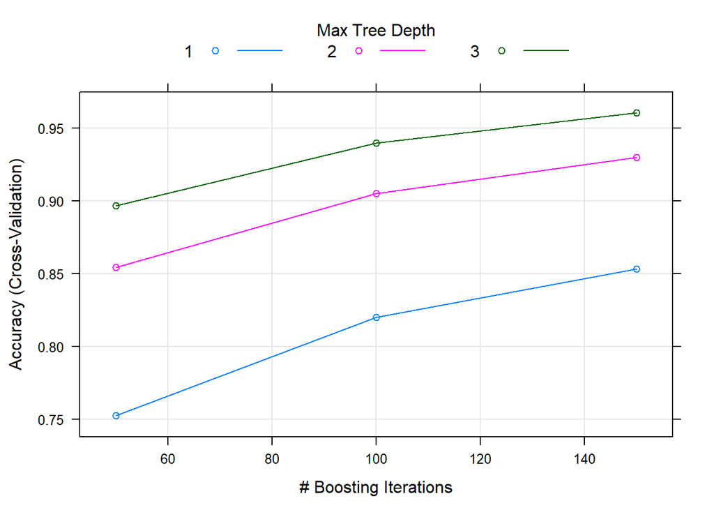

```r
plot(modFitBoost)
```

```r
##Boosting Model Predicition
prediction <- predict(modFitBoost, testing)
test_classe <- as.factor(testing$classe)
confusionMatrix(prediction, test_classe)
```

```
## Confusion Matrix and Statistics
##
##           Reference
## Prediction    A    B    C    D    E
##          A 2184   38    0    0    2
##          B   38 1437   35   13   14
##          C    5   33 1310   30   15
##          D    5    3   20 1239   25
##          E    0    7    3    4 1386
##
## Overall Statistics
##
##                Accuracy : 0.963
##                  95% CI : (0.9586, 0.9671)
##     No Information Rate : 0.2845
##     P-Value [Acc > NIR] : < 2.2e-16
##
##                   Kappa : 0.9533
##
##  Mcnemar's Test P-Value : 1.527e-06
##
## Statistics by Class:
##
##                      Class: A Class: B Class: C Class: D Class: E
## Sensitivity            0.9785   0.9466   0.9576   0.9635   0.9612
## Specificity            0.9929   0.9842   0.9872   0.9919   0.9978
## Pos Pred Value         0.9820   0.9349   0.9404   0.9590   0.9900
## Neg Pred Value         0.9915   0.9872   0.9910   0.9928   0.9913
## Prevalence             0.2845   0.1935   0.1744   0.1639   0.1838
## Detection Rate         0.2784   0.1832   0.1670   0.1579   0.1767
## Detection Prevalence   0.2835   0.1959   0.1775   0.1647   0.1784
## Balanced Accuracy      0.9857   0.9654   0.9724   0.9777   0.9795
```

##Predicition of Test Data #Decision Tree

```r
predictionDT <- predict(modFitDT, dt_testing)
predictionDT
```

```
##             A           B          C          D           E
## 1  0.02695925 0.124764890 0.55047022 0.16865204 0.129153605
## 2  0.78056841 0.169861203 0.01255783 0.02974223 0.007270324
## 3  0.01204819 0.554216867 0.20783133 0.10240964 0.123493976
## 4  0.13606557 0.032786885 0.10655738 0.69344262 0.031147541
## 5  0.71812081 0.130872483 0.01677852 0.11409396 0.020134228
## 6  0.02695925 0.124764890 0.55047022 0.16865204 0.129153605
## 7  0.06504065 0.144308943 0.05284553 0.66463415 0.073170732
## 8  0.71812081 0.130872483 0.01677852 0.11409396 0.020134228
## 9  0.99363057 0.006369427 0.00000000 0.00000000 0.000000000
## 10 0.78056841 0.169861203 0.01255783 0.02974223 0.007270324
## 11 0.02695925 0.124764890 0.55047022 0.16865204 0.129153605
## 12 0.01204819 0.554216867 0.20783133 0.10240964 0.123493976
## 13 0.50735294 0.136029412 0.04411765 0.09191176 0.220588235
## 14 0.99363057 0.006369427 0.00000000 0.00000000 0.000000000
## 15 0.07368421 0.153684211 0.11157895 0.16210526 0.498947368
## 16 0.06299213 0.098425197 0.00000000 0.14960630 0.688976378
## 17 0.96590909 0.000000000 0.02272727 0.00000000 0.011363636
## 18 0.09863946 0.438775510 0.01020408 0.29591837 0.156462585
## 19 0.09863946 0.438775510 0.01020408 0.29591837 0.156462585
## 20 0.01204819 0.554216867 0.20783133 0.10240964 0.123493976
```

```r
#RandomForest
predictionRF <- predict(modFitRF, dt_testing)
predictionRF
```

```
##  1  2  3  4  5  6  7  8  9 10 11 12 13 14 15 16 17 18 19 20
##  B  A  B  A  A  E  D  B  A  A  B  C  B  A  E  E  A  B  B  B
## Levels: A B C D E
```

```r
#Boost
predictionBoost <- predict(modFitBoost, dt_testing)
predictionBoost
```

```
##  [1] B A B A A E D B A A B C B A E E A B B B
## Levels: A B C D E
```